# SVM

shaistamadad

11/15/2020

```r
library(tibble)
library(dplyr)
library(AUC) #
library(e1071)
```

```r
library("pheatmap")
library("RColorBrewer")
library(caret)
library(sigFeature)
library(SummarizedExperiment)
```

# Read in the dataset

```r
D<- read.table("Problem2_expressionMatrix.txt", row.names = 1)
Labels<- read.table("Problem2_patientData.txt", header = TRUE)
D<- as.data.frame(t(D))
# join the labels and predictors
D<- rownames_to_column(D, var = "patient_id")
NewD<- inner_join(D, Labels, by = "patient_id", copy = FALSE, suffix = c(".x", ".y"))
#remove patient name column
df = subset(NewD, select = -c(patient_id) )
#str(df) ## make sure the labels are factors
df$relapse= as.factor(df$relapse)
table(df$relapse)  #should we balance the dataset?
```

```
##
## FALSE  TRUE
##    23    43
```

```r
#str(df$relapse)
dfpredictors= subset(df, select = -c(relapse) )
Y= as.factor(df$relapse)
```

1 to 2 ratio of false to true labels. Although balancing the dataset will reduce the sample size considerably, a higher proportion of true labels can also bias the model. Hence, will run analysis on both balanced and unbalanced datasets and compare the difference in cross validation error.

```r
# divide the data
allFalse<-df[which(df[,"relapse"] == 'FALSE'),] #
allTrue<-df[which(df[,"relapse"] == 'TRUE'),]   #
sample(1:nrow(allTrue), nrow(allFalse))->rand.0
allTrue[rand.0,]->True
allFalse -> False
Balanced_Dataset= rbind(True,False)
dfpredictors_balanced= subset(Balanced_Dataset, select = -c(relapse) )
Y_balanced= as.factor(Balanced_Dataset$relapse)
table(Balanced_Dataset$relapse)
```

```
##
## FALSE  TRUE
##    23    23
```

## Feature Selection

# Feature Selection

3 methods: 1) SVM-SigFeature 2)SVM-RFE 3) Simple T-Test

## Run Feature Selection using SVM-SigFeature

The idea of “sigFeature()” (Significant Feature Selection): The recursive feature elimination that uses support vector machine can rank better classifiers, but those classifiers may or may not be differently significant between the classes. Features with notable classification accuracy and also differentially significant between the classes have a predominant role in a biological aspect. SigFeature is more efficient in ranking classifiers, as well as in determining differently significant classes among them.

```r
sigfeatureRankedList <- sigFeature(dfpredictors, Y)
```

```r
# Choose top 100 genes for SVM model
DFSigFeature=dfpredictors[ ,sigfeatureRankedList[1:100]]
```

```r
sigfeatureRankedList_Balanced<- sigFeature(dfpredictors_balanced, Y_balanced)
```

```r
# Choose top 100 genes for SVM model from balanced dataset
DFSigFeature_balanced=dfpredictors_balanced[ ,sigfeatureRankedList_Balanced[1:100]]
```

## How many of the top 100 genes from balanced and unbalanced datasets are common?

```r
list_df = list(DFSigFeature_balanced,DFSigFeature)

col_common = colnames(list_df[[1]])
for (i in 2:length(list_df)){
  col_common = intersect(col_common, colnames(list_df[[i]]))
}
length(col_common)
```

```
## [1] 65
```

## Hence clearly, balancing the dataset affects the ranking of the top genes

## Run feature selection using SVM-RFE

To solve the classification problem with the help of ranking the features, SVM-RFE is an algorithm (proposed by Guyon et. al 2002). In this algorithm, the dataset has been trained with SVM linear kernel model to produce a weight vector for each feature. After that, the feature with smallest rank is recursively removed and stored in a stack data structure. The iteration process continues till the last feature remains. This criterion is the w value of the decision hyperplane given by the SVM. The weight vector is calculated by squaring the variable w. Finally the features are selected in a list in the descending order.

# Using RFE for feature selection

```r
#Using ubalanced dataset
featureRankedList <- svmrfeFeatureRanking(dfpredictors, Y)
```

```r
DFSVMRFE=dfpredictors[ ,featureRankedList[1:100]]
```

## Using the balanced dataset

```r
featureRankedList_balanced <- svmrfeFeatureRanking(dfpredictors_balanced, Y_balanced)
```

```r
DFSVMRFE_balanced=dfpredictors[ ,featureRankedList_balanced[1:100]]
```

## How many of the top 100 genes from balanced and unbalanced datasets are common using SVM-RFE feature selection?

```r
list_df1 = list(DFSVMRFE_balanced,DFSVMRFE)

col_common1 = colnames(list_df1[[1]])
for (i in 2:length(list_df1)){
  col_common1 = intersect(col_common1, colnames(list_df1[[i]]))
}
length(col_common1)
```

```
## [1] 60
```

## How many of the top 100 genes from balanced datasets are common using SVM-RFE feature selection versus sigFeature?

```r
list_df3 = list(DFSVMRFE_balanced,DFSigFeature_balanced)

col_common3 = colnames(list_df3[[1]])
for (i in 2:length(list_df3)){
  col_common3 = intersect(col_common3, colnames(list_df3[[i]]))
}
length(col_common3)
```

```
## [1] 27
```

## How many of the top 100 genes from unbalanced datasets are common using SVM-RFE feature selection versus sigFeature?

```r
list_df4 = list(DFSVMRFE,DFSigFeature)

col_common4 = colnames(list_df4[[1]])
for (i in 2:length(list_df4)){
  col_common4 = intersect(col_common4, colnames(list_df4[[i]]))
}
length(col_common4)
```

```
## [1] 23
```

# Simple T-Test

```r
ER.pos <- allTrue
ER.pos = subset(ER.pos, select = -c(relapse) )
mu.pos <- apply(ER.pos,2,mean)
var.pos <- apply(ER.pos,2,var)

ER.neg <- allFalse
ER.neg = subset(ER.neg , select = -c(relapse) )
mu.neg <- apply(ER.neg ,2,mean)#compute mean of each column (gene)
var.neg <- apply(ER.neg,2,var)  # compute variance of each column (gene)

meandiff= abs(mu.pos-mu.neg)
npos= length(row.names(ER.pos))
nneg= length(row.names(ER.neg))
ntotal=npos+nneg
denominator= sqrt(((npos-1)* var.pos)+ ((nneg-1)*var.neg))
fac= sqrt((npos*nneg*(ntotal-2))/ntotal)
tscores= (meandiff/denominator)* fac
index <- order(tscores, decreasing=TRUE)
data.sel <- df[,index[1:100]]
best100genes= colnames(data.sel)
```

```r
list_df5 = list(DFSVMRFE,DFSigFeature,data.sel)

col_common5 = colnames(list_df5[[1]])
for (i in 2:length(list_df5)){
  col_common5 = intersect(col_common5, colnames(list_df5[[i]]))
}
length(col_common5)
```

```
## [1] 20
```

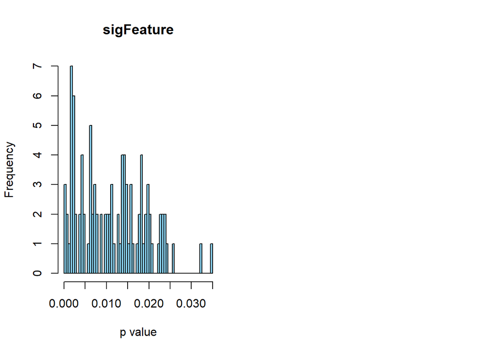

```r
pvalsigFe <- sigFeaturePvalue(dfpredictors, Y, 100, sigfeatureRankedList)
pvalRFE <- sigFeaturePvalue(dfpredictors, Y, 100, featureRankedList)
par(mfrow=c(1,2))
hist(unlist(pvalsigFe),breaks=50, col="skyblue", main=paste("sigFeature"),
     xlab="p value")
```

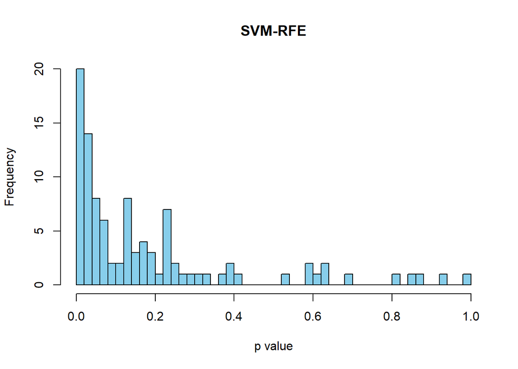

```r
hist(unlist(pvalRFE),breaks=50, col="skyblue",
     main=paste("SVM-RFE"), xlab="p value")
```

a comparison of p values produced by using top 100 features (using “sigFeature” and “SVM-RFE” algorithm) is shown by using scatter box plot.Note the lower p-values for SVM-SigFeature

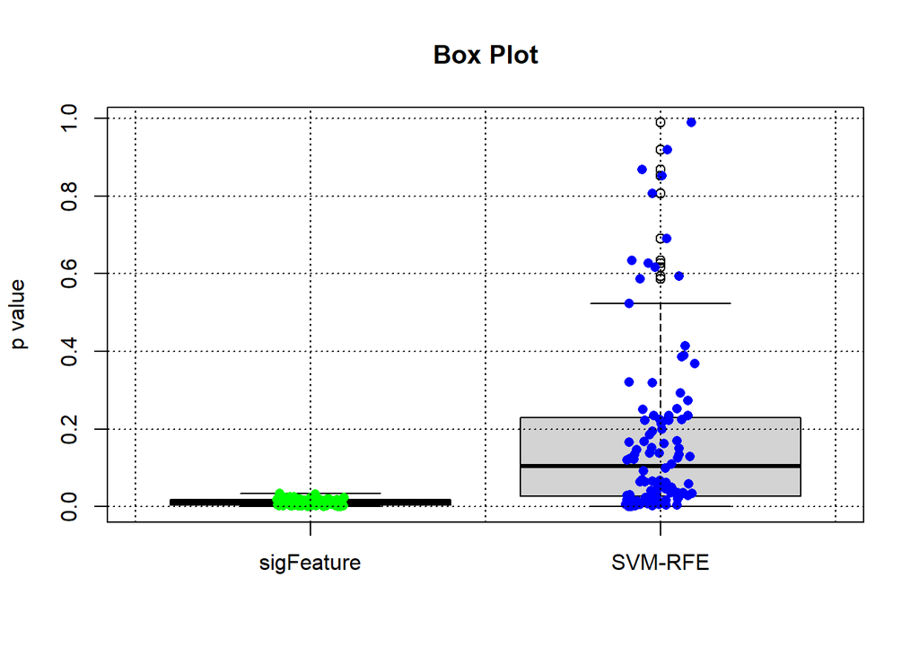

```r
mytitle<-'Box Plot'
boxplot(unlist(pvalsigFe), unlist(pvalRFE), main=mytitle,
        names=c("sigFeature", "SVM-RFE"),
        ylab="p value", ylim=c(min(unlist(pvalsigFe)), max(unlist(pvalRFE))))
stripchart(unlist(pvalsigFe), vertical=TRUE, method="jitter", add=TRUE, pch=16,
           col=c('green'))
stripchart(unlist(pvalRFE), vertical=TRUE, at=2, method="jitter", add=TRUE,
           pch=16, col=c('blue'))
grid(nx=NULL, ny=NULL, col="black", lty="dotted")
```

a heatmap is shown below with the expression value of top 20 features generated by using “sigFeature()” function.

# 20 best genes from SigFeature Scaling

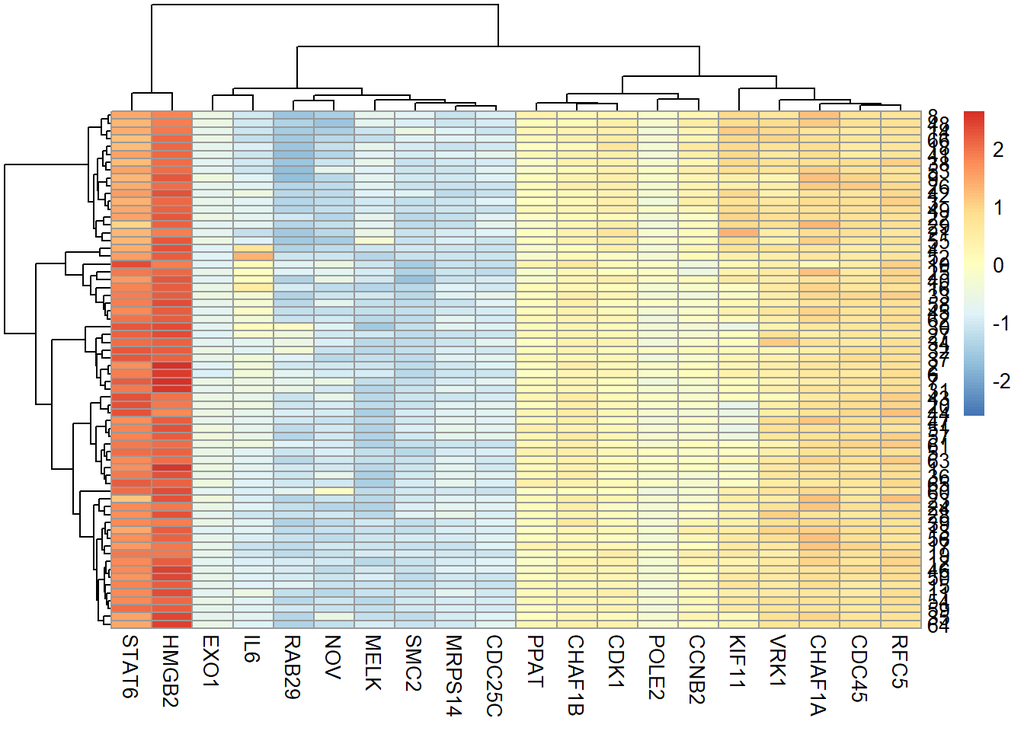

```r
pheatmap(dfpredictors[ ,sigfeatureRankedList[1:20]], scale="row",
         clustering_distance_rows="correlation")
```

a heatmap is shown below with the expression value of top 20 features generated by using “svmrfeFeatureRanking()” function.

# 20 best genes from SVM-RFE feature selection

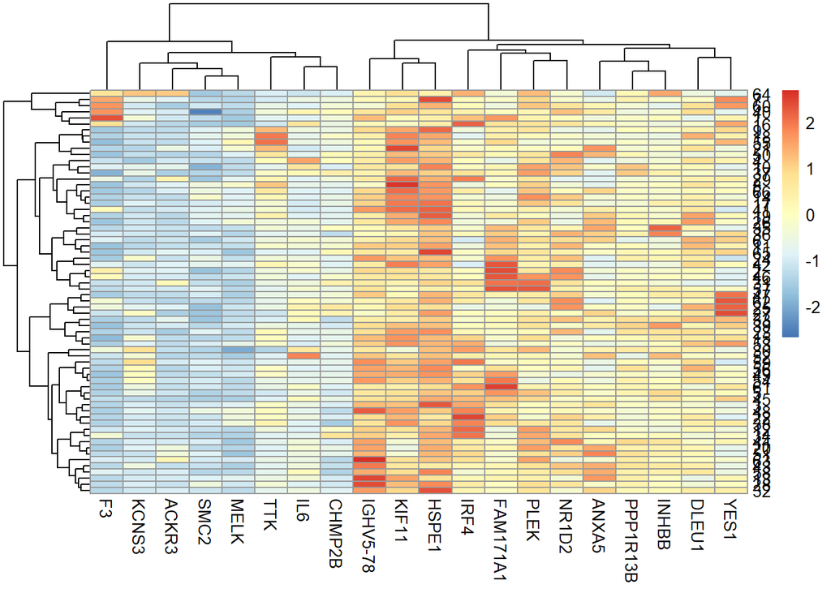

```r
pheatmap(dfpredictors[ ,featureRankedList[1:20]], scale="row",
         clustering_distance_rows="correlation")
```

Hence Best feature selection from the 3 I tried is the sigFeature. ## Run the SVM model on the reduced dataset

Hyperparameters:

1. Kernel: 3 options: linear, radial,polynomial
2. Cost, if choose radial: gamma, if choose polynomial, degree

## Model Building with top 100 features from sigFeature Model Selection

```r
# install.packages('caret')

DFSigFeature$relapse= df$relapse
set.seed(123)
 #Randomly shuffle the data
DFSigFeature<-DFSigFeature[sample(nrow(DFSigFeature)),]
folds = createFolds(DFSigFeature$relapse, k = 10)
# in cv we are going to applying a created function to our 'folds'

cv = lapply(folds, function(x) { # start of function
  #  separate the Training set into it's 10 pieces
  training_fold =DFSigFeature[-x, ] # training fold =  training set minus (-) it's sub test fold
  test_fold =DFSigFeature[x, ] #

  # Tune the cost hyperparameter
  classifier = tune.svm(relapse ~ ., data =training_fold, kernal = "radial",gamma=1/100, cost=seq(from=1, to=20,by=1), probability = T)
  # next step in the loop, we calculate the predictions and cm and we equate the accuracy
  # note we are training on training_fold and testing its accuracy on the test_fold
  y_pred = predict(classifier$best.model, newdata = test_fold[, -ncol(test_fold)])
  cm = table(test_fold[,ncol(test_fold)], y_pred)
  accuracy = (cm[1,1] + cm[2,2]) / (cm[1,1] + cm[2,2] + cm[1,2] + cm[2,1])
  return(accuracy)
})

accuracy = mean(as.numeric(cv))
accuracy
```

```
## [1] 0.7404762
```

## Accuracy using kernel = polynomial

```r
# install.packages('caret')
library(caret)
DFSigFeature$relapse= df$relapse
set.seed(3344)
 #Randomly shuffle the data
DFSigFeature<-DFSigFeature[sample(nrow(DFSigFeature)),]
folds = createFolds(DFSigFeature$relapse, k = 10)
# in cv we are going to applying a created function to our 'folds'

cv = lapply(folds, function(x) { # start of function
  #  separate the Training set into it's 10 pieces
  training_fold =DFSigFeature[-x, ] # training fold =  training set minus (-) it's sub test fold
  test_fold =DFSigFeature[x, ] #

  # Tune the cost hyperparameter
  classifier = tune.svm(relapse ~ ., data =training_fold, kernal = "polynomial", cost=seq(from=1, to=20,by=1), probability = T)
  # next step in the loop, we calculate the predictions and cm and we equate the accuracy
  # note we are training on training_fold and testing its accuracy on the test_fold
  #print(classifier$best.parameters)
  y_pred = predict(classifier$best.model, newdata = test_fold[, -ncol(test_fold)])
  cm = table(test_fold[,ncol(test_fold)], y_pred)
  accuracy = (cm[1,1] + cm[2,2]) / (cm[1,1] + cm[2,2] + cm[1,2] + cm[2,1])
  return(accuracy)
})

accuracy = mean(as.numeric(cv))
accuracy
```

```
## [1] 0.6357143
```

## Accuracy using kernel = linear

```r
# install.packages('caret')
library(caret)
DFSigFeature$relapse= df$relapse
 #Randomly shuffle the data
DFSigFeature<-DFSigFeature[sample(nrow(DFSigFeature)),]
folds = createFolds(DFSigFeature$relapse, k = 10)
# in cv we are going to applying a created function to our 'folds'

cv = lapply(folds, function(x) { # start of function
  #  separate the Training set into it's 10 pieces
  training_fold =DFSigFeature[-x, ] # training fold =  training set minus (-) it's sub test fold
  test_fold =DFSigFeature[x, ] #

  # Tune the cost hyperparameter
  classifier = tune.svm(relapse ~ ., data =training_fold, kernal = "linear", cost=seq(from=1, to=20,by=1), probability = T)
  # next step in the loop, we calculate the predictions and cm and we equate the accuracy
  # note we are training on training_fold and testing its accuracy on the test_fold
  #print(classifier$best.parameters)
  y_pred = predict(classifier$best.model, newdata = test_fold[, -ncol(test_fold)])
  cm = table(test_fold[,ncol(test_fold)], y_pred)
  accuracy = (cm[1,1] + cm[2,2]) / (cm[1,1] + cm[2,2] + cm[1,2] + cm[2,1])
  return(accuracy)
})

accuracy = mean(as.numeric(cv))
accuracy
```

```
## [1] 0.6636905
```

## Accuracy using kernel = radial

```r
# install.packages('caret')
library(caret)
DFSigFeature$relapse= df$relapse
 #Randomly shuffle the data
set.seed(1234)
DFSigFeature<-DFSigFeature[sample(nrow(DFSigFeature)),]
folds = createFolds(DFSigFeature$relapse, k = 10)
# in cv we are going to applying a created function to our 'folds'

cv = lapply(folds, function(x) { # start of function
  #  separate the Training set into it's 10 pieces
  training_fold =DFSigFeature[-x, ] # training fold =  training set minus (-) it's sub test fold
  test_fold =DFSigFeature[x, ] #

  # Tune the cost hyperparameter
  classifier = tune.svm(relapse ~ ., data =training_fold, kernal = "radial", cost=seq(from=1, to=20,by=1), probability = T)
  # next step in the loop, we calculate the predictions and cm and we equate the accuracy
  # note we are training on training_fold and testing its accuracy on the test_fold
  #print(classifier$best.parameters)
  y_pred = predict(classifier$best.model, newdata = test_fold[, -ncol(test_fold)])
  cm = table(test_fold[,ncol(test_fold)], y_pred)
  accuracy = (cm[1,1] + cm[2,2]) / (cm[1,1] + cm[2,2] + cm[1,2] + cm[2,1])
  return(accuracy)
})

accuracy = mean(as.numeric(cv))
accuracy
```

```
## [1] 0.6386905
```

## Accuracy using kernel = polynomial

```r
# install.packages('caret')
library(caret)
set.seed(123455)
 #Randomly shuffle the data
df= df[sample(nrow(df)),]
folds = createFolds(df$relapse, k = 10)
# in cv we are going to applying a created function to our 'folds'

cv = lapply(folds, function(x) { # start of function
  #  separate the Training set into it's 10 pieces
  training_fold =df[-x, ] # training fold =  training set minus (-) it's sub test fold
  test_fold =df[x, ] #

  # Tune the cost hyperparameter
  classifier = tune.svm(relapse ~ ., data =training_fold, kernal = "polynomial", cost=seq(from=1, to=20,by=1), probability = T)
  # next step in the loop, we calculate the predictions and cm and we equate the accuracy
  # note we are training on training_fold and testing its accuracy on the test_fold
  #print(classifier$best.parameters)
  y_pred = predict(classifier$best.model, newdata = test_fold[, -ncol(test_fold)])
  cm = table(test_fold[,ncol(test_fold)], y_pred)
  accuracy = (cm[1,1] + cm[2,2]) / (cm[1,1] + cm[2,2] + cm[1,2] + cm[2,1])
  return(accuracy)
})

accuracy = mean(as.numeric(cv))
accuracy
```

```
## [1] 0.7285714
```

```r
bestModel= dfpredictors_balanced[ ,sigfeatureRankedList[1:100]]
bestModel$relapse= Balanced_Dataset$relapse
bestModel<-bestModel[sample(nrow(bestModel)),]
folds = createFolds(bestModel$relapse, k = 10)

cv = lapply(folds, function(x) { # start of function
  #  separate the Training set into it's 10 pieces
  training_fold =bestModel[-x, ] # training fold =  training set minus (-) it's sub test fold
  test_fold =bestModel[x, ] #


  classifier = svm(relapse ~ ., data =training_fold, kernal = "polynomial", cost=1, probability = T)
  # next step in the loop, we calculate the predictions and cm and we equate the accuracy
  # note we are training on training_fold and testing its accuracy on the test_fold
  #print(classifier$best.parameters)
  y_pred = predict(classifier, newdata = test_fold[, -ncol(test_fold)])
  cm = table(test_fold[,ncol(test_fold)], y_pred)
  accuracy = (cm[1,1] + cm[2,2]) / (cm[1,1] + cm[2,2] + cm[1,2] + cm[2,1])
  return(accuracy)
})

accuracy = mean(as.numeric(cv))
accuracy
```

```
## [1] 0.72
```